# White Wine Exploration by Elisa Marchione

# Multivariate Plots Section

Now I’d like to dive further into more complex relationships between the different variables. I want to compare some of the different variables that have strong correlations and see how they tend to impact the quality rating given to the different wines.

I decided to create another variable to help bucket the quality variable. I’m hoping that I’ll be able to see some trends by doing this.

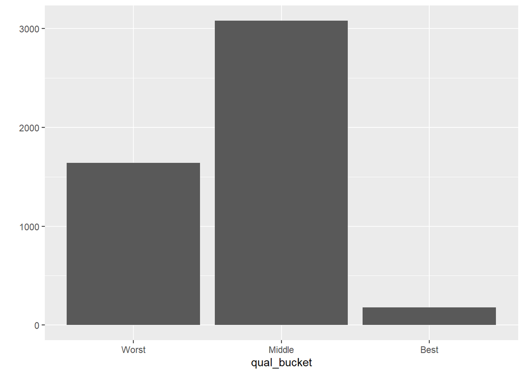

As is consistent with the overall distribution of quality ratings, most of the wines are part of the “middle” qual_bucket.

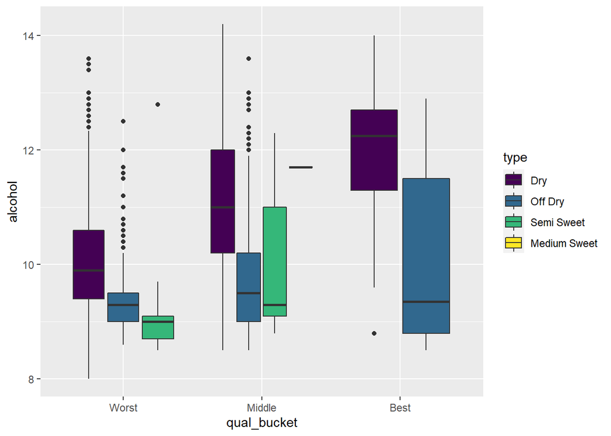

It’s useful to see a breakdown of the types of wine. The trend of higher alcohol values for higher quality is still apparent.

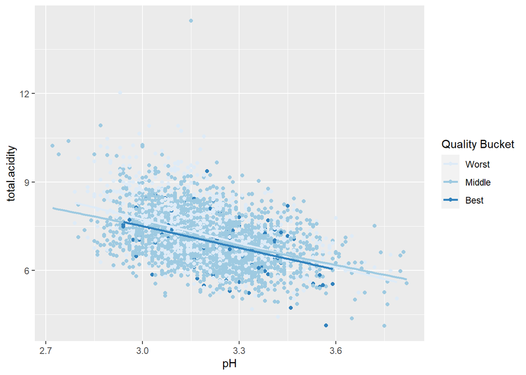

Comparing total.acidity to pH with qual_bucket doesn’t provide any additional insight into that relationship.

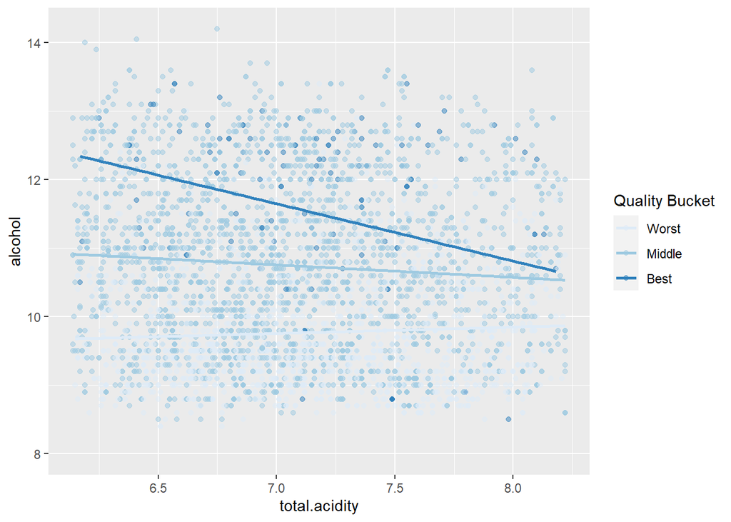

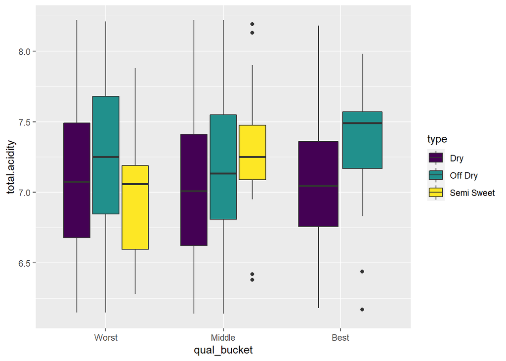

The combination of total.acidity and alcohol does not seem to have a correlation with quality.

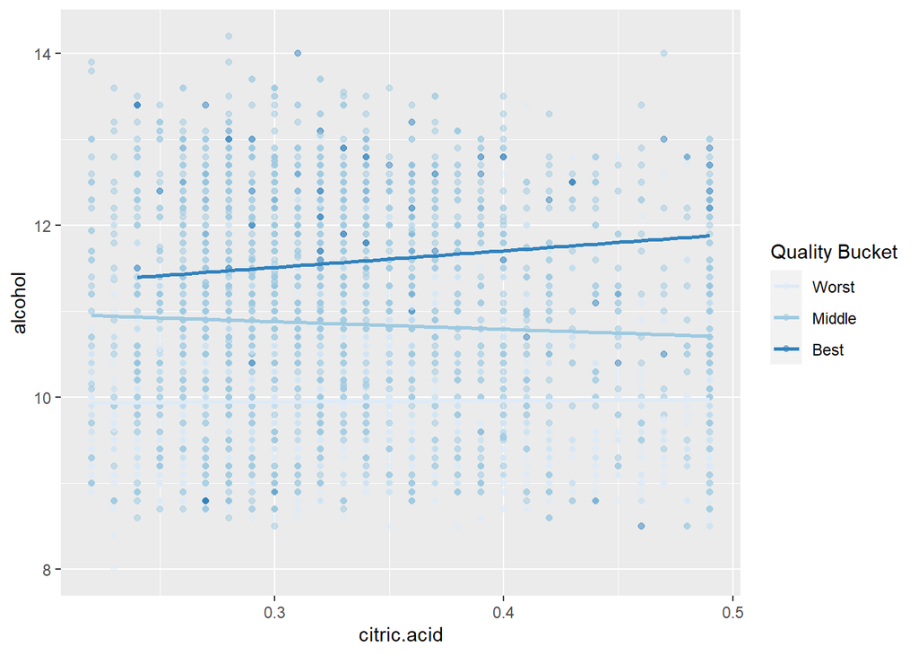

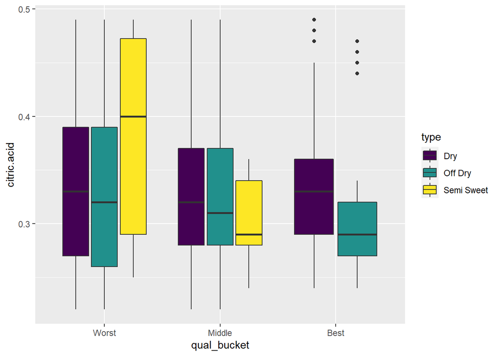

I don’t see any specific trends with citric.acid and quality.

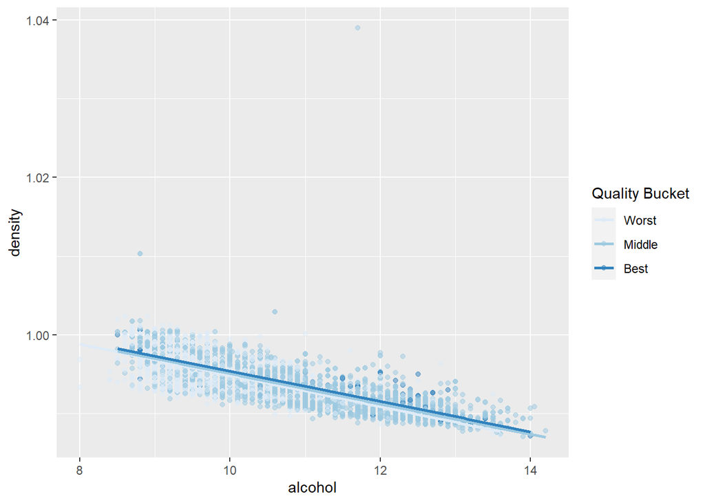

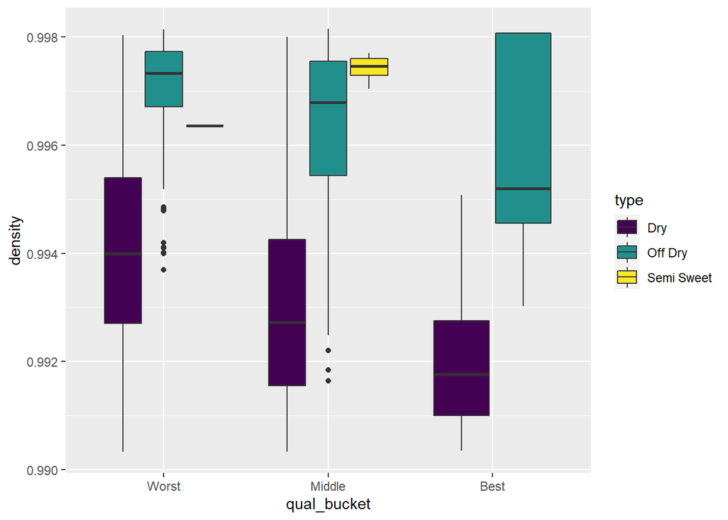

While there is correlation between alcohol and density, I don’t see additional insight by looking at quality or type.

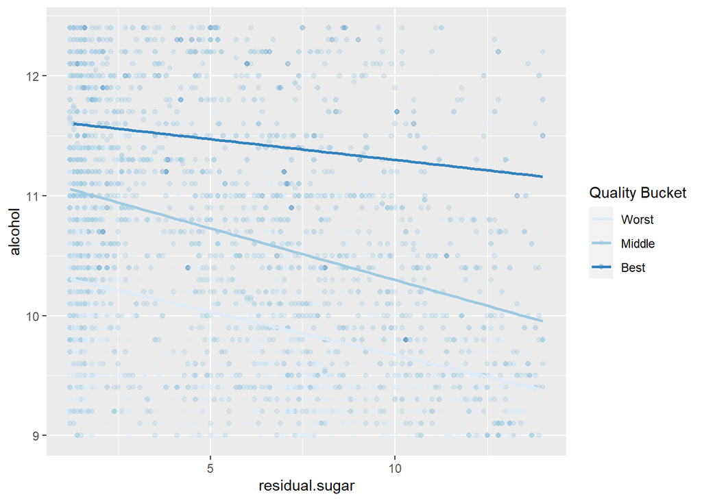

There does seem to be some relationship between alcohol level, residual.sugar and quality. The best quality wines appear to have more alcohol and less residual.sugar.

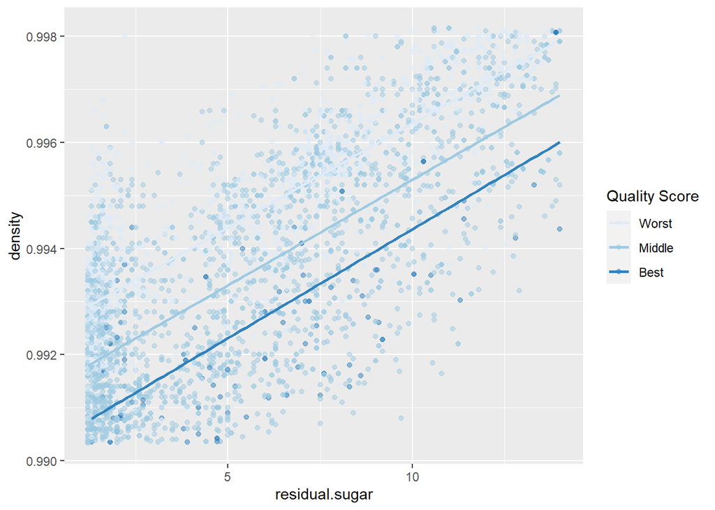

Finally, looking at the combination of density, residual.sugar and quality, I can see that the best quality wines have the lowest densities and residual.sugar values.

# Multivariate Analysis

### Talk about some of the relationships you observed in this part of the investigation. Were there features that strengthened each other in terms of looking at your feature of interest?

Alcohol level seems to continue having an impact on quality, no matter the chemical property. The best wines were generally at the top of alcohol level, though the chemical properties studied had a variety of distributions.

The relationship between pH and total.acidity did stay consistent, but there didn’t seem to be an impact on quality.

### Were there any interesting or surprising interactions between features?

I was surprised that it was hard to find a clear cut relationship between the different chemical properties on quality. It seemed that the biggest factor on quality was the alcohol level. That appeared to be the only consistent variable.

# Final Plots and Summary

### Plot One

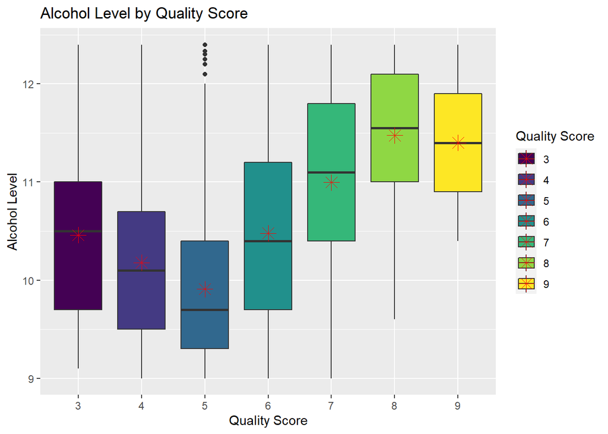

### Plot Two

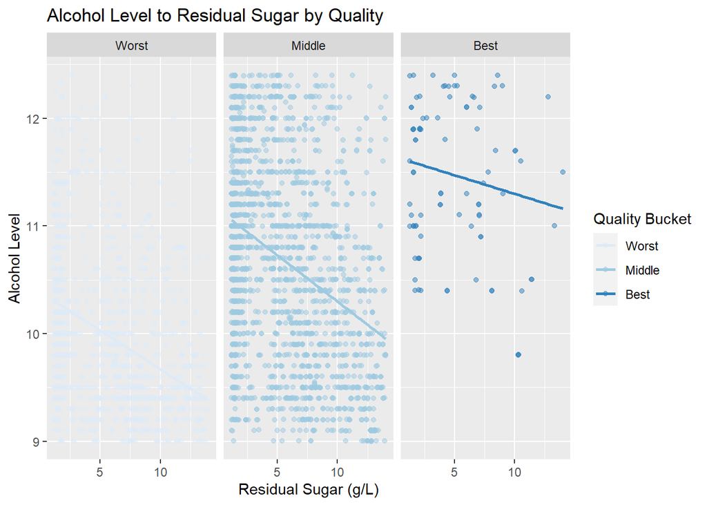

### Description Two

Comparing residual.sugar and alcohol level to the quality bucket showed that there is some interaction between these two variables. The best wines have high alcohol levels and low to mid values for residual.sugar.

### Plot Three

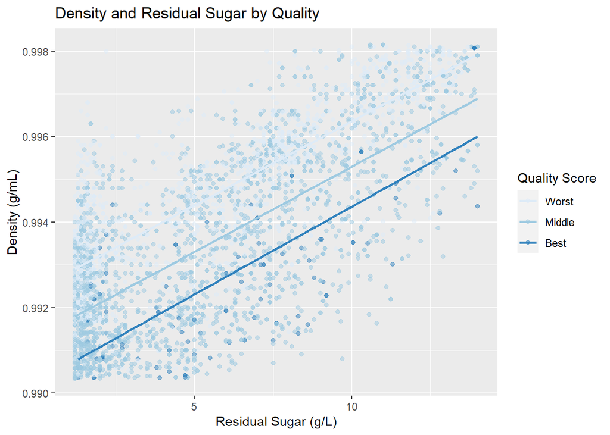

### Description Three

This plot shows the positive correlation between residual.sugar and density. It also shows that the higher quality wines have lower residual.sugar and density values.

# Reflection

It was useful to just run a bunch of quick and dirty plots and see what popped up in the data, and then to dive into it more by updating the plots with better binwidths, alpha values, scales and colors. I liked to create a base plot and then just update the variable being used to create a number of different plots. It made it easy to quickly get some basic ideas about possible correlations.

I enjoyed the fact that I was able to create new variables to further categorize the data. It was helpful to do domain research so that I could better understand the variables and how they might likely interact.

I did have some struggles with the project. One of the biggest issues I had was that none of my variables were a measure of time, so I didn’t feel like I could do line graphs. I felt restricted to scatterplots, boxplots and summary statistics. It was definitely harder to compare multiple variables because of this as well. I tried to stick to using at least one categorical variable, so I was definitely glad that I was able to create some of those for use in my analysis.

I also struggled with knowing how to massage the charts to show better information. There were a few tricks that I was able to use many times, such as setting the limits as quantile probabilities. This did make me feel like I was just doing the same thing over and over again sometimes. But it was still useful to see what impacts it had on the visualizations of my data.

I found that RStudio was really nice to use for quick, easy visualizations; however, the longer that the project got, it became rather time-consuming to have to go through and run each snippet of code again so I could make sure that I had all the necessary dataframes and variables setup correctly.

I think that my analysis could definitely benefit from further work and research. With the direction that I took with this analysis, I didn’t seem to find a way to create a model for determining quality. I believe that it is possible, but it would require deeper analysis into all of the different variables, and a deeper understanding of the complex interactions between chemical variables.

I also wonder about the limitations of having a dataset that focused strictly on white wines. I feel like having a dataset of red wine data would make it even more possible to come up with a model for determining quality based on the chemical properties. And while there were almost 5000 different wines studied, the amount of best quality wines was much lower. I suppose that’s to be expected, but I can’t help but feel like an even bigger sample size would have helped further differentiate between variables.

All in all, this was a great project that helped me really understand the possibilities of EDA and how to use R and RStudio effectively to assist with analysis. I feel like I’ve added even more knowledge and resources to my data analysis tool belt, and I’m excited to do even more with it.